# 6,243 Introduction to Programming

Lecture 3: Git with others

Dr. Franziska Bender, Dr. Aurélien Sallin

2025-09-16

## Goals for today

In this lecture and exercise session, we will:

- go remote with our repository
- set up a collaborative project on git

## Vision

Collaborate on programming/data science projects.

## You have been working locally, what now?

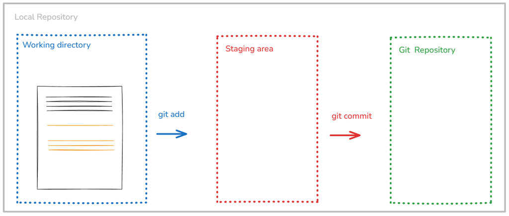

Three levels: changes can be either **unstaged**, **staged** or **commited**.

- When we first make a change it is unstaged
- Once we **add** the change to the staging area it is **staged**
- We can then **commit** all staged changes

## `push` and `pull` to communicate with the world

[figure not shown]

## What is GitHub?

- GitHub is a website to host git repositories
- By having your git repository online, you can easily collaborate with others
- Similar, alternative websites like Bitbucket or GitLab

## Why having your code on GitHub?

- Backup of your project (you can work from different machines)
- Collaboration in groups and also with people you don’t know
- Free and Open-Source Software (FOSS)
- Visibility as Coder (your porfolio - GitHub fulfills some function of a social network for programmers)

## Github.com: a demo

Check some interesting **GitHub repositories**: PaddleOCR, an open-source optical character recognition, or [Awesome Datascience](https://github.com/academic/awesome-datascience), a full collection of resources on data science

Or **GitHub pages**, like [the GitHub profile of the World Bank](https://github.com/worldbank) or [build your own](https://github.com/codecrafters-io/build-your-own-x) page with “build-your-own” projects.

# Connecting git and github

## Authenticating with GitHub 🗝️

#### Authentication when pushing and pulling

- When you connect to a GitHub repository, GitHub needs to verify who you are using a username and password. Since August 2021 stronger authentication is required, and there are several secure methods available.
- We’ll use **SSH keys**: you keep a private key on your computer and upload the matching public key to GitHub; when they match correctly, GitHub grants access.
- Using SSH keys is more secure than passwords, avoids repeated credential prompts, and is a common, portable method for authenticating to remote services.

#### How to?

- Setting up the authentication with GitHub could be somewhat cumbersome.
- Please go to this [website from LMU Munich](https://lmu-osc.github.io/Introduction-RStudio-Git-GitHub/SSH.html) and follow the steps to authenticate with GitHub.  
  *Credits*: Open Science Center at LMU Munich (Mike Croucher & Malika Ihle)

## Test your connection

Test your connection using the following code.

```bash
ssh -T git@github.com
> Hi ASallin! You've successfully authenticated, but GitHub does not provide shell access.
```

## Cloning a Repository

- You can download repositories from GitHub (and anywhere else), by **cloning** them
- For public repositories, `git clone` just works, for private ones you will need to be authenticated
- `git clone <remote URL>`

## Cloning the course repository

Remember our course structure:

```
BECON_4222_Introduction_programming/
├── materials/              # is empty for now, you will clone the git repo in week 3
├── exercises/              # Student's own work
│   ├── week01/
│   ├── week02/
│   ├── ...
│   ├── week12/
├── group_project/
│   ├── ...
```

## Cloning the course repository

##### 2. Find the HTTPS or SSH on the GitHub course repo

[figure not shown]

You can find the remote URL by going to a repository on GitHub and clicking the Code button

## Cloning the course repository

##### 3. Clone the course repository.

The course is public, so cloning via HTTPS will work without an SSH key; cloning via the SSH URL requires a configured SSH key.

```bash
git clone https://github.com/ASallin/BECON_4222_Introduction_Programming.git
```

or

```bash
git clone git@github.com:ASallin/BECON_4222_Introduction_Programming.git
```

## Cloning the course repository

Now you’ve cloned the course repository in your directory. You’ll have a new folder called “BECON_4222_Introduction_Programming”. You can remove the “materials” folder.

```
BECON_4222_Introduction_programming/
├── BECON_4222_Introduction_Programming/
├── exercises/              # Student's own work
│   ├── week01/
│   ├── week02/
│   ├── ...
│   ├── week12/
├── group_project/
│   ├── ...
```

Every week, you can refresh the course content with `git pull`.

# Remotes

## Remotes

- A **remote** is a version of your repository stored on a website like GitHub.
- Remotes also have branches, just like your local repository.
- The main remote is usually called `origin`.
  - If you use `git clone`, the remote named `origin` is set up for you automatically.

## Adding a Remote

When you want to add an **existing** repository to GitHub, you will have to add the remote yourself

```bash
git remote add <remote name> <remote URL>
```

It only works if you are not in a repo which has already been linked to a remote.

```bash
git remote add origin git@github.com:asallin/BECON_4222_Introduction_Programming.git
```

To learn about all possible commands for remotes use `-h`

```bash
git remote -h
```

# Syncing Changes

## Syncing Changes: Overview

You first `pull` the latest changes from the remote and then `push` your own changes.

[figure not shown]

## Getting Changes: `git pull`

- To get the newest updates from GitHub, type `git pull` in your terminal.
- This command downloads any changes from the online repository and adds them to your current work.
- Usually, your branch is already set up to follow the matching branch on GitHub.
  - If it isn’t, Git will show you a warning and tell you what to do.

```bash
# Pull from the tracked remote branch
git pull

# Pull from a specific branch
git pull <remote> <branch>
```

- `git pull` does does things under the hood: it fetches the latest changes and merges them into the current branch.
- (You can also run `git fetch` to fetch the latest changes and then `git merge <remote>/branch` to merge them)

## Note on Getting Changes: `git pull`

- When you run `git pull` for the first time, you will need to choose a default *merge strategy*
- When you receive the message, just copy this line of code (or the one you prefer)

```bash
# Default to merge
git config pull.rebase false
```

## Pushing Your Changes: `git push`

- You can send *your* changes to github by running `git push`
- This only works if there are no new changes at the remote
  - If there have been changes since your last `pull` you need to `pull` again

```bash
# Push to the tracked remote branch
git push

# Push a branch to the remote for the first time
# -u is short for --set-upstream
git push -u <remote> <branch>
```